# Housing Bubble

Utkuhan Genc

July 10, 2018

## How to install EVDS R package?

We first need to install the EVDS package. This is a API wrapper for Central Bank of Republic of Turkey’s official database EVDS.

```r
devtools::install_github("algopoly/EVDS")
```

We need to use some packages to get and to analyze the data. **If these packages are not already installed please install them before starting.**

```r
#options(Encoding="UTF-8")
getOption("encoding")
```

```
## [1] "native.enc"
```

```r
library(tidyverse)
library(EVDS)
library(lubridate)
library(zoo)
library(sp)
library(corrplot)
library(mapproj)
#data.table package is added.
library(data.table)
```

We start by setting our API key. You can get your API key from [EVDS website](https://evds2.tcmb.gov.tr/), from your profile page.

```r
set_evds_key("YOURAPIKEY")
```

## Introduction

After exploring some of the series on the website I decided to make an analysis on Residential Property Prices Indices in Turkey. The reason behind this to analyze the housing bubble in Turkey and how does it differ by location.

RPPIs help people to further understand where to invest while buying properties. The guidelines on how these indices are explained in Handbook on Residential Property Prices Indices (RPPIs) prepared by Eurostat which can be accesesd through [here](http://ec.europa.eu/eurostat/documents/3859598/5925925/KS-RA-12-022-EN.PDF/df645fcf-7d99-4926-ad20-3263980954da).

First, I am going to analyze both the house price index and the hedonic house price index for Turkey and it’s three biggest cities: Istanbul, Izmir, Ankara. The reason I am doing this first is to show the difference between hedonic house price index and house price index. The need for the hedonic price index is explained by a study made by Türkiye Cumhuriyeti Merkez Bankasi/ Central Bank of Republic of Turkey in 2016. It states that: > This increase is widespread across the country where prices are even doubled in some regions. Our study performs a hedonic price adjustment for the housing market in Turkey, where we control for the price effects of increases in observed house characteristics in time.

Hedonic price index is a regression model based pricing properties’ chracteristics. This chracteristics include the built year of he property, number of toilets, the quality of the building and etc. Further information about these chracteristics and the methodology could be find [here](http://www.tcmb.gov.tr/wps/wcm/connect/fbb9fbe5-d357-4e43-bf2d-4f1da4153614/en1602eng.pdf?MOD=AJPERES&CACHEID=ROOTWORKSPACE-fbb9fbe5-d357-4e43-bf2d-4f1da4153614-m3fw5q3).

## Preparing Data

By using `get_series` function, we can get the data we want from the EVDS website. As seen below, the function takes 3 arguments: Series names, start date and end date. All dates should be in `dd-mm-YYYY` format. There is another argument `date_format` but default is `dmY`.

As I stated before I will use the data for Turkey and it’s three biggest cities in my first analysis.

I will list the variable names that I used in this analysis and what they correspond on EVDS website in a list format.

- **TP.01TKFE** = House price index (general)
- **TP.02TR10** = House price index (Istanbul)
- **TP.03TR51** = House price index (Ankara)
- **TP.04TR31** = House price index (Izmir)
- **TP.HKFE01** = Hedonic house price index (general)
- **TP.HKFE02** = Hedonic house price index (Istanbul)
- **TP.HKFE03** = Hedonic house price index (Ankara)
- **TP.HKFE04** = Hedonic house price index (Izmir)

```r
#Getting house price index for Istanbul, Izmir and Ankara

house_index <- get_series(series = c("TP.01TKFE","TP.02TR10", "TP.03TR51","TP.04TR31"), start_date = "01-01-2010", end_date = "01-04-2018" )
house_index <- house_index$items %>%
  select(-UNIXTIME) %>%
  transmute(date = Tarih, House_Istanbul = TP_02TR10, House_Ankara = TP_03TR51, House_Izmir = TP_04TR31, House = TP_01TKFE)

#Getting hedonic house price index for Istanbul, Izmi and Ankara

hedonic_index <- get_series(series = c("TP.HKFE02", "TP.HKFE03", "TP.HKFE04","TP.HKFE01"), start_date = "01-01-2010", end_date = "01-04-2018" )
hedonic_index <- hedonic_index$items %>%
  select(-UNIXTIME) %>%
   transmute(date = Tarih, Hedonic_Istanbul = TP_HKFE02, Hedonic_Ankara = TP_HKFE03, Hedonic_Izmir = TP_HKFE04, Hedonic_House = TP_HKFE01)

df <- left_join(house_index, hedonic_index, by = "date")

df1 <- df %>%
  gather(key=serie,value = value,-date) %>%
  mutate(index_type = ifelse(serie %in% c("Hedonic_House", "Hedonic_Istanbul", "Hedonic_Izmir", "Hedonic_Ankara"), "Hedonic House Price Index", "House Price Index"))
```

### Plot 1

This graph shows the diffrence between the hedonic house price index and the house price index.

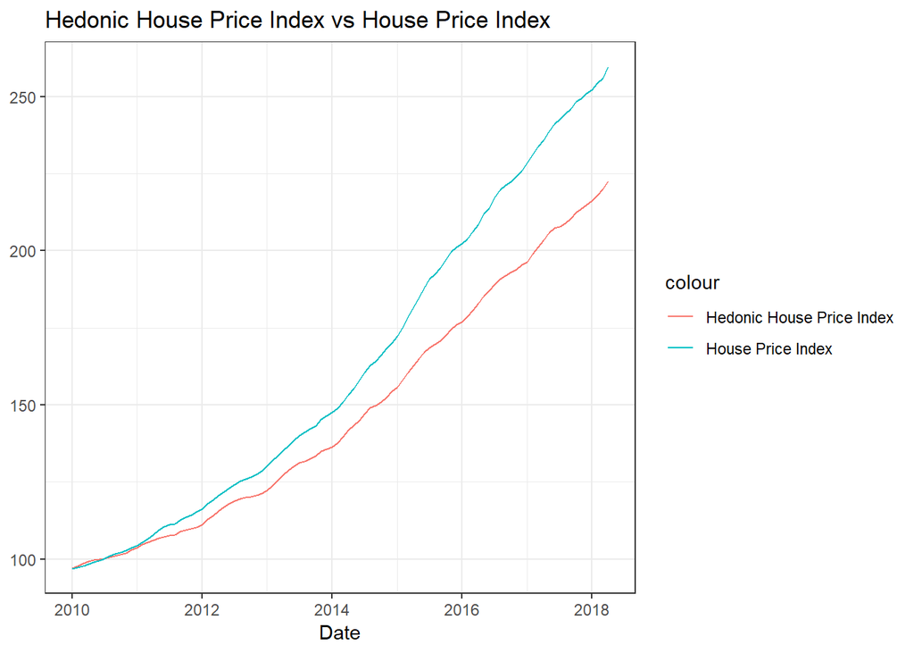

```r
## y values converted to numeric

ggplot(df) + geom_line(aes(x = as.yearmon(date), y=as.numeric(Hedonic_House), color = "Hedonic House Price Index")) +
  geom_line(aes(x = as.yearmon(date), y=as.numeric(House), color = "House Price Index")) +
  labs(x = "Date", y = NULL , title  = "Hedonic House Price Index vs House Price Index")+
  theme_bw()
```

### Plot 2

This graph visiualise the house price index and hedonic price index for Turkey and it’S three biggest cities.

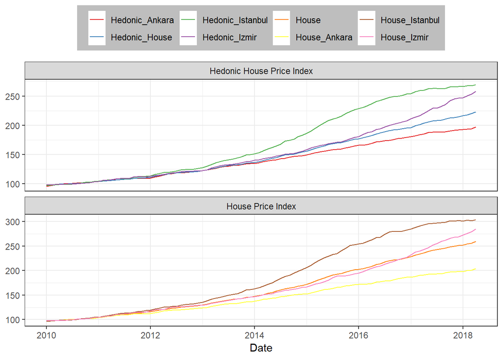

```r
## y values converted to numeric
ggplot(df1, aes(x=as.yearmon(date),y=as.numeric(value),color=serie)) +
  geom_line() +
  facet_wrap(~factor(index_type), scales = "free_y", dir  = "v") +
  theme_bw()+
  theme(legend.position="top" , legend.background = element_rect(fill="gray")) +
  labs(x= "Date" , y=NULL) +
  scale_color_brewer("", palette = "Set1")
```

These two graphs show hedonic house price index increases more gradually than house price index and this ensures better result comparison between years. Also, as seen from the graph Istanbul is finally settling down however Izmir is on the rise in terms of price indices. Ankara has below average as expected. Especially after 2015, house price indices increased precipitiously in general. This can be explained by the Turkish goverment’s increased focus on construction industry. It will be wise to remember that The CBRT introduced hedonic house price indices in 2010 after a big leap in construction output to control this growth.

## Hedonic Price Analysis - Correlation

After seeing the different increases among the three big cities, I wanted to further analysis each city and their hedonic price index. I will look into how much the index changed per year. EVDS divides all the cities in 26 different regions. These regions and which cities they consist can be seen at table below. I used the metadata given by CRBT to name this regions. This document can be viewed at [here](http://www.tcmb.gov.tr/wps/wcm/connect/b4628fa9-11a7-4426-aee6-dae67fc56200/KFE-Metaveri.pdf?MOD=AJPERES&CACHEID=ROOTWORKSPACE-b4628fa9-11a7-4426-aee6-dae67fc56200-m8KAKBK).

| Name | Cities |
| --- | --- |
| TR_10 | Istanbul |
| TR_21 | Edirne, Kirklareli, Tekirdag |
| TR_22 | Balikesir, Çanakkale |
| TR_31 | Izmir |
| TR_32 | Aydin, Denizli, Mugla |
| TR_33 | Afyonkarahisar, Kütahya, Manisa, Usak |
| TR_41 | Bursa, Eskisehir, Bilecik |
| TR_42 | Bolu, Kocaeli, Sakarya, Yalova, Düzce |
| TR_51 | Ankara |
| TR_52 | Konya, Karaman |
| TR_61 | Antalya, Burdur, Isparta |
| TR_62 | Adana, Mersin |
| TR_63 | Hatay, Kahramanmaras, Osmaniye |
| TR_71 | Nevsehir, Nigde, Aksaray, Kirikkale, Kirsehir |
| TR_72 | Kayseri, Sivas, Yozgat |
| TR_81 | Zonguldak, Bartin, Karabük |
| TR_82 | Çankiri, Kastamonu, Sinop |
| TR_83 | Samsun, Çorum, Amasya, Tokat |
| TR_90 | Artvin, Giresun, Gümüshane, Ordu, Rize, Trabzon |
| TR_A1 | Erzurum, Erzincan, Bayburt |
| TR_A2 | Agri, Ardahan, Kars, Igdir |
| TR_B1 | Bingöl, Elazig, Malatya, Tunceli |
| TR_B2 | Van, Bitlis, Hakkâri, Mus |
| TR_C1 | Kilis, Adiyaman, Gaziantep |
| TR_C2 | Diyarbakir, Sanliurfa |
| TR_C3 | Batman, Mardin, Siirt, Sirnak |

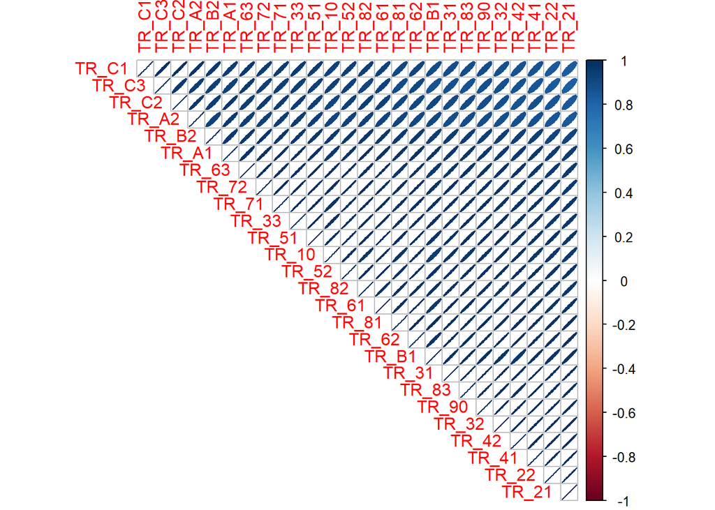

```r
df <- get_series(series = c("TP.HKFE02","TP.HKFE03","TP.HKFE04","TP.HKFE05","TP.HKFE06","TP.HKFE07","TP.HKFE08","TP.HKFE09","TP.HKFE10","TP.HKFE11","TP.HKFE12","TP.HKFE13","TP.HKFE14","TP.HKFE15","TP.HKFE16","TP.HKFE17","TP.HKFE18","TP.HKFE19","TP.HKFE20","TP.HKFE21","TP.HKFE22","TP.HKFE23","TP.HKFE24","TP.HKFE25","TP.HKFE26","TP.HKFE27"),start_date = "01-01-2010", end_date = "01-12-2010" )

df <- df$items %>%
  select(-c(UNIXTIME,Tarih))

#convert data from char to numeric
df<-df%>%mutate_if(is.character,as.numeric)

  df<-df%>%summarise_all(funs(mean)) %>%
  mutate(Tarih = "2010-4")

df1 <- get_series(series = c("TP.HKFE02","TP.HKFE03","TP.HKFE04","TP.HKFE05","TP.HKFE06","TP.HKFE07","TP.HKFE08","TP.HKFE09","TP.HKFE10","TP.HKFE11","TP.HKFE12","TP.HKFE13","TP.HKFE14","TP.HKFE15","TP.HKFE16","TP.HKFE17","TP.HKFE18","TP.HKFE19","TP.HKFE20","TP.HKFE21","TP.HKFE22","TP.HKFE23","TP.HKFE24","TP.HKFE25","TP.HKFE26","TP.HKFE27"),start_date = "01-01-2011", end_date = "01-04-2018" )

df1 <-df1$items %>% select(-UNIXTIME)

# create temp to keep tarih then;
temp<-data.table(tarih<-df1$Tarih)
# convert char to numeric (tarih is na here, we will get tarih from temp with code below)
df1<-df1%>%mutate_if(is.character,as.numeric)
# then assign tarih again
df1$Tarih<-temp$V1

hedonic_cities <- dplyr::bind_rows(df,df1)

cities_corr <- hedonic_cities %>%
  select(-Tarih) %>%
  transmute(TR_10 = TP_HKFE02, TR_21 = TP_HKFE05, TR_22 = TP_HKFE06, TR_31 = TP_HKFE04, TR_32 = TP_HKFE07, TR_33 = TP_HKFE08, TR_41 = TP_HKFE09, TR_42 = TP_HKFE10, TR_51 = TP_HKFE03, TR_52 = TP_HKFE11, TR_61 = TP_HKFE12, TR_62 = TP_HKFE13, TR_63= TP_HKFE14, TR_71 = TP_HKFE15, TR_72 = TP_HKFE16, TR_81 = TP_HKFE17, TR_82 = TP_HKFE18, TR_83 = TP_HKFE19, TR_90 = TP_HKFE20, TR_A1 = TP_HKFE21, TR_A2 = TP_HKFE22, TR_B1 = TP_HKFE23, TR_B2 = TP_HKFE24, TR_C1 = TP_HKFE25, TR_C2 = TP_HKFE26, TR_C3 = TP_HKFE27)

cities_corr <- cor(cities_corr)

corrplot(cities_corr, method = "ellipse" , type = "upper", order = "AOE")
```

## Hedonic House Price Index

Lastly, I want to look at the hedonic house price indices for every city individually.To analyze differences I decided to look at the annual percentage change of each city. To visualize I am going to put percentage change of each city on the Turkey map. To get this map you need to go to this [link](https://gadm.org/download_country_v3.html) and select `Turkey`. From there you need to select `R (SpatialPolygonsDataFrame)`and `level 1`. If you are working with counties, you need to select `level 2`. However this data has some spelling errors which might cause some problems when graphing. That’s why I am going to use computer_friendlying function that you can see below to fix these errors.

```r
#Sys.setlocale(locale="Turkish_Turkey.1254") #Windows

#new text conversions are below

computer_friendlying<-function(mytext,spaceas="-"){
  mytext<-gsub(" ",spaceas,mytext)
  mytext<-gsub("ç","c",mytext)
  mytext<-gsub("s","s",mytext)
  mytext<-gsub("ğ","g",mytext)
  mytext<-gsub("ü","u",mytext)
  mytext<-gsub("ö","o",mytext)
  mytext<-gsub("ı","i",mytext)
  mytext<-gsub("Ç","C",mytext)
  mytext<-gsub("S","S",mytext)
  mytext<-gsub("G","G",mytext)
  mytext<-gsub("Ü","U",mytext)
  mytext<-gsub("Ö","O",mytext)
  mytext<-gsub("I","I",mytext)
  return(mytext)
}
```

## Fixing TURKEY map data

```r
TUR <- readRDS("gadm36_TUR_1_sp.rds")
TUR_for <- fortify(TUR)
turdata_renamed <- computer_friendlying(TUR@data$NAME_1)
turdata_renamed <- gsub("Kinkkale", "Kirikkale",turdata_renamed)
turdata_renamed <- gsub("Zinguldak", "Zonguldak",turdata_renamed)
turdata_renamed <- gsub("K\\.\\-Maras", "Kahramanmaras",turdata_renamed)

print(turdata_renamed)
```

```
##  [1] "Adana"         "Adiyaman"      "Afyon"         "Agri"
##  [5] "Aksaray"       "Amasya"        "Ankara"        "Antalya"
##  [9] "Ardahan"       "Artvin"        "Aydin"         "Balikesir"
## [13] "Bartin"        "Batman"        "Bayburt"       "Bilecik"
## [17] "Bingol"        "Bitlis"        "Bolu"          "Burdur"
## [21] "Bursa"         "Canakkale"     "Cankiri"       "Corum"
## [25] "Denizli"       "Diyarbakir"    "Duzce"         "Edirne"
## [29] "Elazig"        "Erzincan"      "Erzurum"       "Eskisehir"
## [33] "Gaziantep"     "Giresun"       "Gumushane"     "Hakkari"
## [37] "Hatay"         "Igdir"         "Isparta"       "Istanbul"
## [41] "Izmir"         "Kahramanmaras" "Karabuk"       "Karaman"
## [45] "Kars"          "Kastamonu"     "Kayseri"       "Kilis"
## [49] "Kirikkale"     "Kirklareli"    "Kirsehir"      "Kocaeli"
## [53] "Konya"         "Kutahya"       "Malatya"       "Manisa"
## [57] "Mardin"        "Mersin"        "Mugla"         "Mus"
## [61] "Nevsehir"      "Nigde"         "Ordu"          "Osmaniye"
## [65] "Rize"          "Sakarya"       "Samsun"        "Sanliurfa"
## [69] "Siirt"         "Sinop"         "Sirnak"        "Sivas"
## [73] "Tekirdag"      "Tokat"         "Trabzon"       "Tunceli"
## [77] "Usak"          "Van"           "Yalova"        "Yozgat"
## [81] "Zonguldak"
```

```r
#Function to calculate percentage change

pct <- function(x) {(x/lag(x,1) *100 - 100)}

#Turkey map with latitude and longitude

# new city assignments below
cities_pct <- hedonic_cities %>%
  transmute(Adana = TP_HKFE13, Adiyaman = TP_HKFE25, Afyon = TP_HKFE08, Agri = TP_HKFE22, Aksaray = TP_HKFE15, Amasya = TP_HKFE19, Ankara = TP_HKFE03, Antalya = TP_HKFE12, Ardahan = TP_HKFE22, Artvin = TP_HKFE20, Aydin =  TP_HKFE07, Balikesir = TP_HKFE06, Bartin = TP_HKFE17, Batman = TP_HKFE27, Bayburt = TP_HKFE21, Bilecik =  TP_HKFE09, Bingol = TP_HKFE23, Bitlis = TP_HKFE24, Bolu = TP_HKFE10, Burdur = TP_HKFE12, Bursa = TP_HKFE09, Canakkale = TP_HKFE06, Cankiri = TP_HKFE18, Corum = TP_HKFE19, Denizli = TP_HKFE07, Diyarbakir = TP_HKFE26, Duzce = TP_HKFE10, Edirne = TP_HKFE05, Elazig = TP_HKFE23, Erzincan = TP_HKFE21, Erzurum = TP_HKFE21, Eskisehir = TP_HKFE09, Gaziantep = TP_HKFE25, Giresun = TP_HKFE20, Gumushane =  TP_HKFE20, Hakkari = TP_HKFE24, Hatay = TP_HKFE14, Igdir = TP_HKFE22,  Isparta = TP_HKFE12, Istanbul = TP_HKFE02, Izmir = TP_HKFE04,  Kahramanmaras =  TP_HKFE14, Karabuk = TP_HKFE17, Karaman = TP_HKFE11, Kars = TP_HKFE22, Kastamonu = TP_HKFE18, Kayseri = TP_HKFE16, Kilis = TP_HKFE25, Kirikkale = TP_HKFE15, Kirklareli = TP_HKFE05, Kirsehir = TP_HKFE15, Kocaeli = TP_HKFE10, Konya = TP_HKFE11, Kutahya = TP_HKFE08, Malatya = TP_HKFE23, Manisa = TP_HKFE08, Mardin = TP_HKFE27,  Mersin = TP_HKFE13, Mugla = TP_HKFE07, Mus = TP_HKFE24, Nevsehir = TP_HKFE15, Nigde = TP_HKFE15,  Ordu = TP_HKFE20, Osmaniye = TP_HKFE14, Rize = TP_HKFE20, Sakarya =TP_HKFE10, Samsun = TP_HKFE19, Sanliurfa = TP_HKFE26, Siirt =  TP_HKFE27, Sinop = TP_HKFE18, Sirnak = TP_HKFE27, Sivas = TP_HKFE16, Tekirdag = TP_HKFE05, Tokat = TP_HKFE19, Trabzon = TP_HKFE20, Tunceli = TP_HKFE23, Usak = TP_HKFE08, Van = TP_HKFE24, Yalova = TP_HKFE10, Yozgat = TP_HKFE16, Zonguldak=  TP_HKFE17, Date = Tarih ) %>%
  # we change mutate_each function to mutate_at
  filter(str_detect(Date, "-4")) %>% mutate_at(vars(-Date),funs(pct)) %>% filter(str_detect(Date,"2018-4")) %>% select(-Date) %>% gather() %>% tbl_df()



df2 <- data_frame(id = rownames(TUR@data), key = turdata_renamed) %>%
  left_join(cities_pct, by = "key") %>% as.data.frame()

print(df2)
```

```
##    id           key     value
## 1   1         Adana  9.000853
## 2  12      Adiyaman  6.784539
## 3  23         Afyon  9.591796
## 4  34          Agri -2.427539
## 5  45       Aksaray  9.338363
## 6  56        Amasya 13.644481
## 7  67        Ankara  6.488385
## 8  78       Antalya 10.215814
## 9  81       Ardahan -2.427539
## 10  2        Artvin  9.465402
## 11  3         Aydin 13.535632
## 12  4     Balikesir 13.685166
## 13  5        Bartin 10.276848
## 14  6        Batman  1.785934
```

[output cut: 67 more lines]

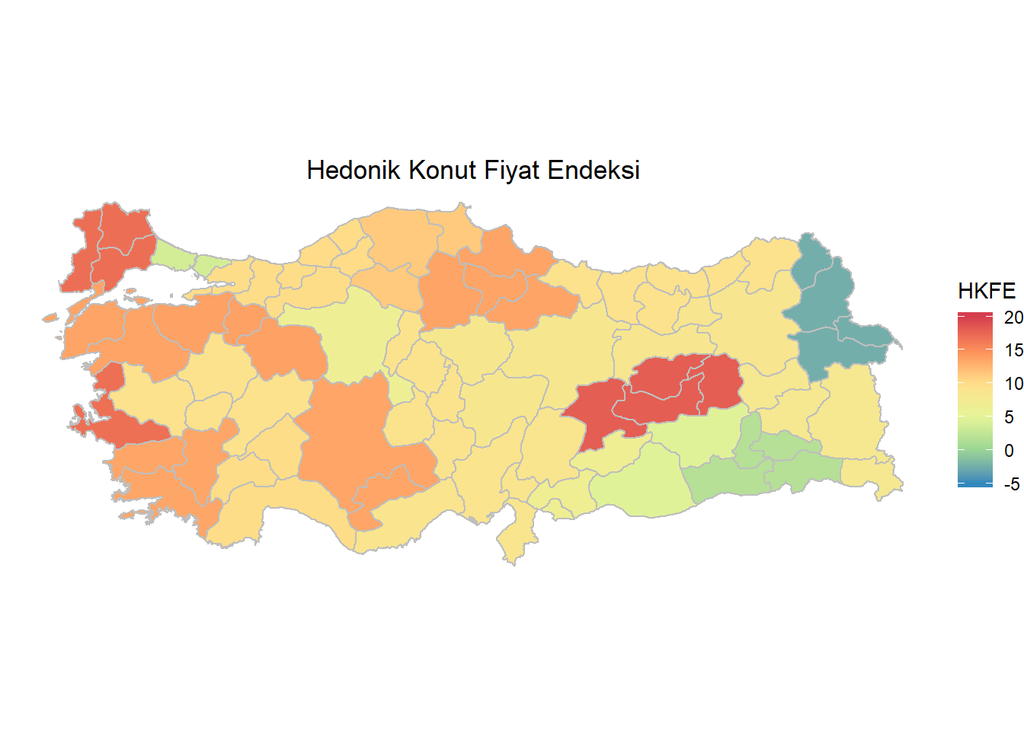

```r
final_map <- left_join(TUR_for, df2, by = "id")


ggplot(final_map) +
  geom_polygon( aes(x = long, y = lat, group = group, fill = value),
                color = "grey") +
  coord_map() +
  theme_void() +
  labs(title = "Hedonik Konut Fiyat Endeksi") +
  scale_fill_distiller(name = "HKFE",
                       palette = "Spectral", limits = c(-5,20), na.value = "black") +
  theme(plot.title = element_text(hjust = 0.5),
        plot.subtitle = element_text(hjust = 0.5))
```